### Fish by island (PISCO data)

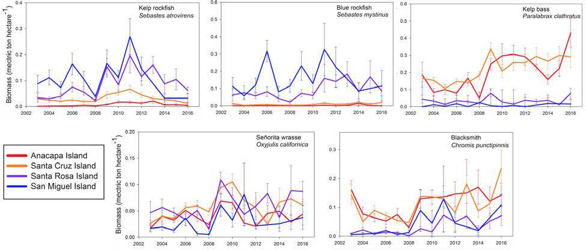

**Figure App.F.13.15.**. A figure showing the average mass of five kelp-forest fish species found in kelp forests, from four of the Northern Channel Islands from 2003 - 2016.

**Click for Details**

Average biomass of five kelp forest fish species at 14 [PISCO](http://www.piscoweb.org/) monitoring sites across four islands in Channel Islands National Marine Sanctuary from 2003—2016. Fish are counted by SCUBA divers swimming along transect lines. Fish density was averaged across all monitoring sites at each island, including sites located inside and outside of marine reserves and conservation areas, to examine course-scale trends by island. At a finer scale, fish density is responding differently inside and outside of some marine protected areas (MPAs) in CINMS. A discussion of MPA effects in CINMS is available in MPA Effects. Data source: [PISCO](http://www.piscoweb.org/); Figure: NOAA

### Fish by island (CINP data)

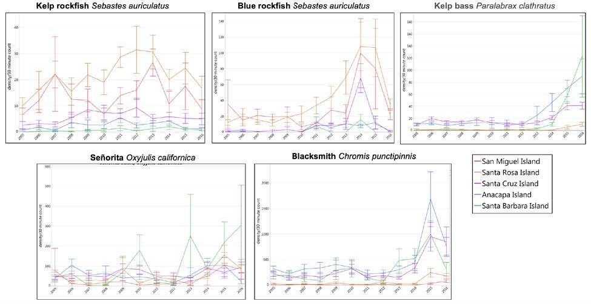

**Click for Details**

Average density of five kelp forest fish species at Channel Islands National Park kelp forest monitoring sites at the five islands in Channel Islands National Marine Sanctuary. Fish density was averaged across all monitoring sites at each island, including sites located inside and outside of marine reserves and conservation areas, to examine course-scale trends by island. At a finer scale, fish density is responding differently inside and outside of some marine protected areas (MPAs) in CINMS. A discussion of MPA effects in CINMS is available in MPA Effects. Figure: [Channel Islands National Park](https://www.nps.gov/chis/index.htm)

### Fish island vs. mainland (SBC-LTER data)

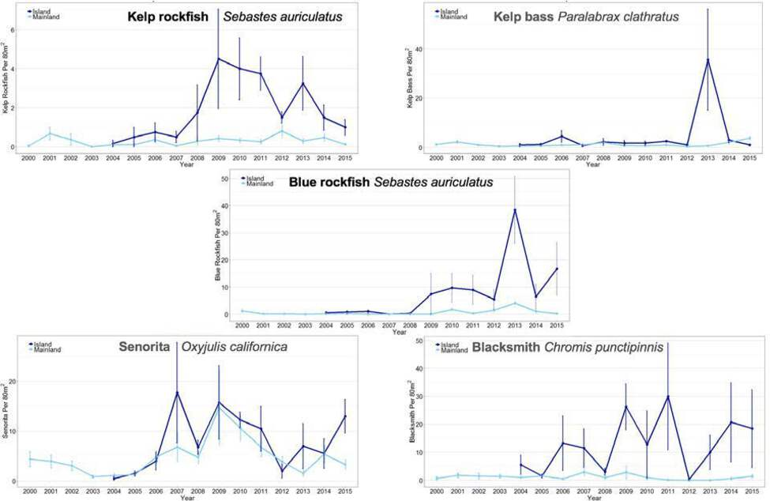

**Figure App.F.13.17.**. A figure showing a comparison of the average density of five kelp-forest fish species from two of the Northern Channel Islands to mainland sites from 2000 - 2015.

**Click for Details**

Mean (+/- SE) density of five kelp forest fish species at two island (dark blue) and nine mainland (light blue) sites monitored by the [Santa Barbara Channel Long-term Ecological Research (SBC LTER)](https://sbclter.msi.ucsb.edu/) program. Data source: SBC LTER; Figure: [R. Freedman/NOAA](https://channelislands.noaa.gov/contact/freedman.html)

### Giant sea bass (*Stereolepis gigas*) (PISCO data)

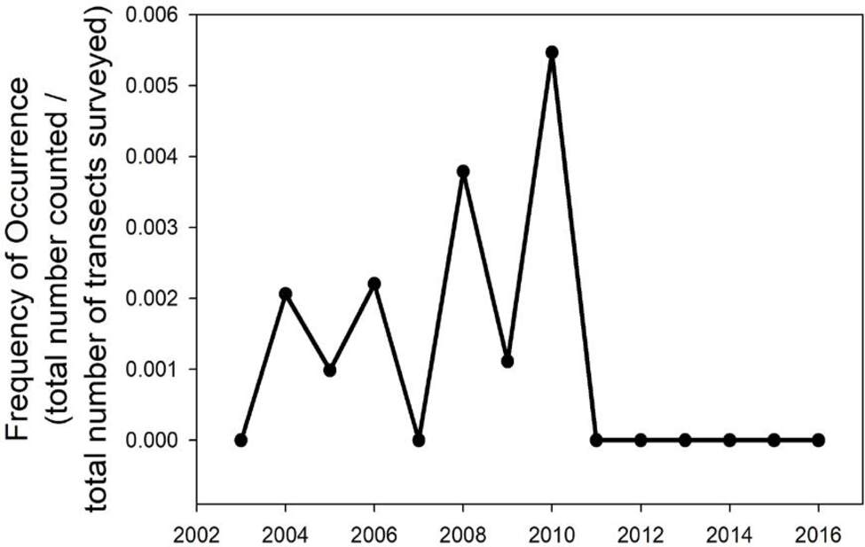

**Figure App.F.13.14.**. A figure showing the number of times giant sea bass were present at sampling sites across the Channel Islands from 2003 - 2016.

**Click for Details**

Frequency of occurrence of giant sea bass *Stereolepis gigas* at 14 [PISCO](http://www.piscoweb.org/) monitoring sites in Channel Islands National Marine Sanctuary from 2003—2016. Note that this species is so rare that there are too few observations to detect a trend, if one exists, but it is notable that this species has not been sighted during surveys since 2011. Data source: PISCO; Figure: [R. Freedman/NOAA](https://channelislands.noaa.gov/contact/freedman.html)